# Basic Modeling

N.Paterno

## Building a Linear Model

For this lab we will be trying to predict the difference between the starting price and final price (not including shipping) for a Mario Kart game auctioned on ebay. Let’s take a look at our dataset.

```r
glimpse(mariokart)
```

```
## Rows: 143
## Columns: 12
## $ id          <dbl> 150377422259, 260483376854, 320432342985, 280405224677,...
## $ duration    <int> 3, 7, 3, 3, 1, 3, 1, 1, 3, 7, 1, 1, 1, 1, 7, 7, 3, 3, 1...
## $ n_bids      <int> 20, 13, 16, 18, 20, 19, 13, 15, 29, 8, 15, 15, 13, 16, ...
## $ cond        <fct> new, used, new, new, new, new, used, new, used, used, n...
## $ start_pr    <dbl> 0.99, 0.99, 0.99, 0.99, 0.01, 0.99, 0.01, 1.00, 0.99, 1...
## $ ship_pr     <dbl> 4.00, 3.99, 3.50, 0.00, 0.00, 4.00, 0.00, 2.99, 4.00, 4...
## $ total_pr    <dbl> 51.55, 37.04, 45.50, 44.00, 71.00, 45.00, 37.02, 53.99,...
## $ ship_sp     <fct> standard, firstClass, firstClass, standard, media, stan...
## $ seller_rate <int> 1580, 365, 998, 7, 820, 270144, 7284, 4858, 27, 201, 48...
## $ stock_photo <fct> yes, yes, no, yes, yes, yes, yes, yes, yes, no, yes, ye...
## $ wheels      <int> 1, 1, 1, 1, 2, 0, 0, 2, 1, 1, 2, 2, 2, 2, 1, 0, 1, 1, 2...
## $ title       <fct> "~~ Wii MARIO KART &amp; WHEEL ~ NINTENDO Wii ~ BRAND N...
```

We want to predict the difference of the start and final price of the game itself. Looking at the pricing variables given we have *start_Pr* (starting price), *ship_Pr* (shipping price) and *total_Pr* (total price). This means we need to do a bit of work to get the variable we want. Below I’ll clean the data - to get rid of unnecessary variables - and add the new variable.

```r
model_data <- mariokart %>%
  select(n_bids, duration ,start_pr, ship_pr, total_pr) %>% #This line selects the variable we might need for our model.
  mutate(price_diff = total_pr-ship_pr-start_pr) #This line calculates the difference between start and final price for each auction.
```

## Finding the Correlation Coefficient

Next, we’ll use a function from the *moderndive* package to calculate a few linear correlation coefficients and see if there are any relationships worth modeling.

```r
get_correlation(data = model_data, price_diff ~ duration)
```

```
## # A tibble: 1 x 1
##      cor
##    <dbl>
## 1 -0.144
```

```r
get_correlation(data = model_data, price_diff ~ n_bids)
```

```
## # A tibble: 1 x 1
##     cor
##   <dbl>
## 1 0.464
```

## Looking for a Better Fit

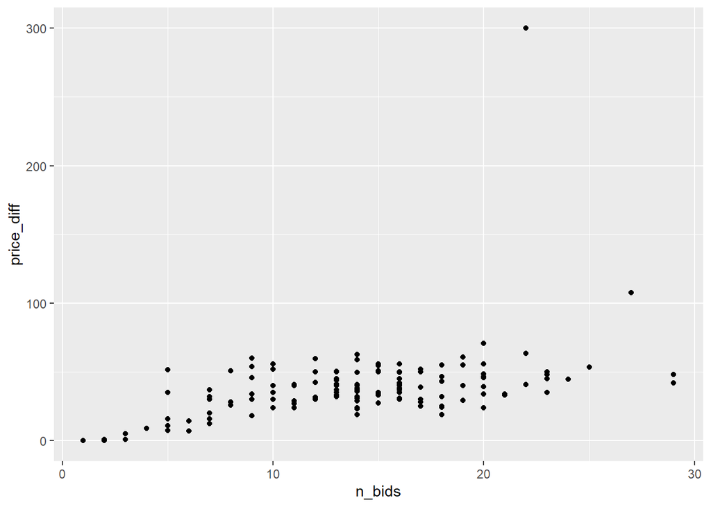

```r
ggplot(model_data, aes(n_bids, price_diff))+
  geom_point()
```

```r
model_data_2 <- model_data %>%
  filter(price_diff<300)

get_correlation(data = model_data_2, price_diff ~ n_bids)
```

```
## # A tibble: 1 x 1
##     cor
##   <dbl>
## 1 0.621
```

This is a much better correlation. We’ll use this dataset to build our model.

## Building the Linear Model

```r
price_model <- lm(data = model_data_2, price_diff ~ n_bids)
```

Next we’ll overlay the model onto our scatter plot.

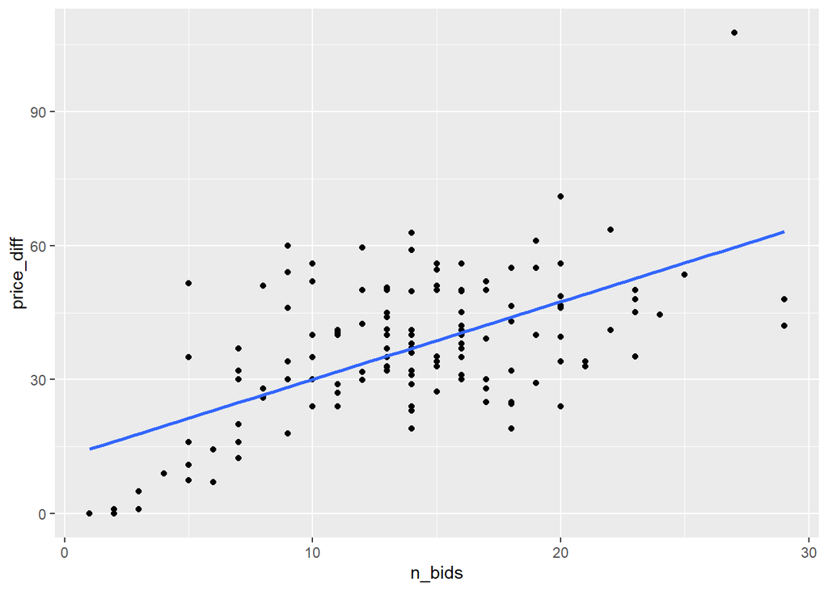

```r
ggplot(model_data_2, aes(n_bids, price_diff))+
  geom_point()+
  geom_smooth(method = "lm",
              se = FALSE)
```

## Analyzing the Model

Now we’ll look at a summary of the model.

```r
get_regression_table(price_model)
```

```
## # A tibble: 2 x 7
##   term      estimate std_error statistic p_value lower_ci upper_ci
##   <chr>        <dbl>     <dbl>     <dbl>   <dbl>    <dbl>    <dbl>
## 1 intercept    12.7      2.72       4.66       0     7.32    18.1
## 2 n_bids        1.74     0.186      9.36       0     1.37     2.10
```

The *intercept* row is for the y-intercept of the line. Based on our data, the model shows an intercept of 12.702 and a standard error of 2.725; This leads to a confidence interval of (7.315, 18.090). For this row we aren’t concerned about the (test) statistic or p_value.

## Making Predictions

Now that our model is built, let’s make some predictions. To do this, we’ll need to write a function that takes in a model and value and returns a prediction.

```r
model_prediction <- function(model, value){ #This line defines our function.
  return(model$coefficients[1]+value*model$coefficients[2]) #This line calculates the prediction by evaluating the linear function at the supplied value and returns the result.
}
```

We’ll make two predictions: an interpolation (within the original data cluster) and an extrapolation (a point away from the original data cluster).

Interpolation:

```r
model_prediction(price_model, 15)
```

```
## (Intercept)
##    38.75632
```

Based on our model, an ebay auction for Mario Kart that receive 15 bids will have a $38.76 increase from the starting price to the final price.

Extrapolation:

```r
model_prediction(price_model, 100)
```

```
## (Intercept)
##    186.3955
```

Based on our model, an ebay auction for Mario Kart that receive 100 bids will have a $186.40 increase from the starting price to the final price.